# week_07_continue_visualizations

## CMPINF 2100 Fall 2021 - Week 07

### Continue continuous - to - continuous relationships

```python
import numpy as np
import pandas as pd
import matplotlib.pyplot as plt

import seaborn as sns
```

```python
penguins = sns.load_dataset('penguins')
```

```python
penguins
```

|  | species | island | bill_length_mm | bill_depth_mm | flipper_length_mm | body_mass_g | sex |
| --- | --- | --- | --- | --- | --- | --- | --- |
| 0 | Adelie | Torgersen | 39.1 | 18.7 | 181.0 | 3750.0 | Male |
| 1 | Adelie | Torgersen | 39.5 | 17.4 | 186.0 | 3800.0 | Female |
| 2 | Adelie | Torgersen | 40.3 | 18.0 | 195.0 | 3250.0 | Female |
| 3 | Adelie | Torgersen | NaN | NaN | NaN | NaN | NaN |
| 4 | Adelie | Torgersen | 36.7 | 19.3 | 193.0 | 3450.0 | Female |
| ... | ... | ... | ... | ... | ... | ... | ... |
| 339 | Gentoo | Biscoe | NaN | NaN | NaN | NaN | NaN |
| 340 | Gentoo | Biscoe | 46.8 | 14.3 | 215.0 | 4850.0 | Female |
| 341 | Gentoo | Biscoe | 50.4 | 15.7 | 222.0 | 5750.0 | Male |
| 342 | Gentoo | Biscoe | 45.2 | 14.8 | 212.0 | 5200.0 | Female |
| 343 | Gentoo | Biscoe | 49.9 | 16.1 | 213.0 | 5400.0 | Male |

344 rows × 7 columns

```python
penguins.info()
```

```
<class 'pandas.core.frame.DataFrame'>
RangeIndex: 344 entries, 0 to 343
Data columns (total 7 columns):
 #   Column             Non-Null Count  Dtype
---  ------             --------------  -----
 0   species            344 non-null    object
 1   island             344 non-null    object
 2   bill_length_mm     342 non-null    float64
 3   bill_depth_mm      342 non-null    float64
 4   flipper_length_mm  342 non-null    float64
 5   body_mass_g        342 non-null    float64
 6   sex                333 non-null    object
dtypes: float64(4), object(3)
memory usage: 18.9+ KB
```

Last week we ended by considering relationships between continuous variables. We used scatter plots.

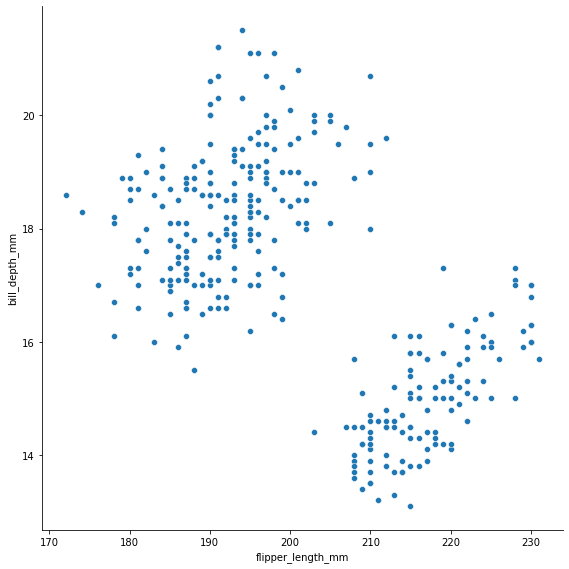

```python
sns.relplot(data = penguins, x='flipper_length_mm', y='bill_depth_mm', height=8)

plt.show()
```

Trend lines to show the **linear** relationship between the two variables.

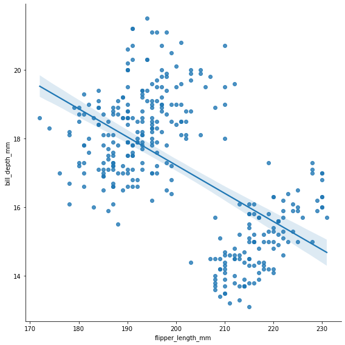

```python
sns.lmplot(data = penguins, x='flipper_length_mm', y='bill_depth_mm', height=8)

plt.show()
```

Group by a categorical variable to show the relationships change across groups.

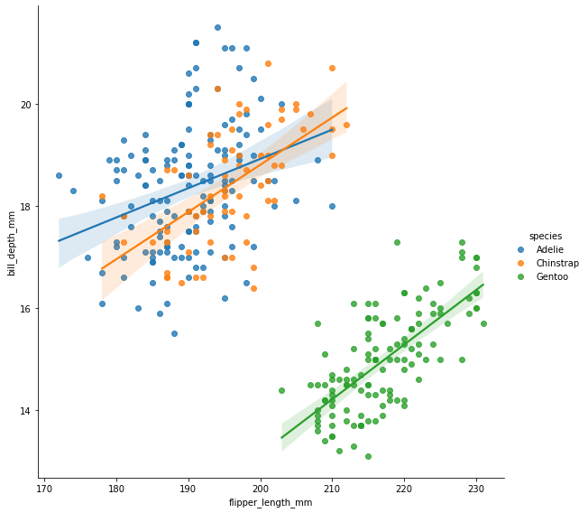

```python
sns.lmplot(data = penguins, x='flipper_length_mm', y = 'bill_depth_mm', hue='species', height=8)

plt.show()
```

## Correlation coefficients

Calculate the correlation coefficient between two variables in the DataFrame.

```python
penguins.loc[:, ['flipper_length_mm', 'bill_depth_mm']].corr()
```

|  | flipper_length_mm | bill_depth_mm |
| --- | --- | --- |
| flipper_length_mm | 1.000000 | -0.583851 |
| bill_depth_mm | -0.583851 | 1.000000 |

Visualize the correlation plot as a heat map.

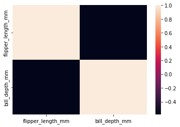

```python
fig, ax = plt.subplots()

sns.heatmap(data = penguins.loc[:, ['flipper_length_mm', 'bill_depth_mm']].corr(),
            ax=ax)

plt.show()
```

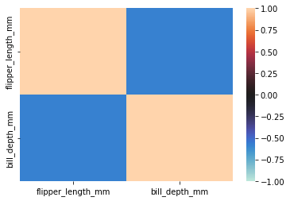

```python
fig, ax = plt.subplots()

sns.heatmap(data = penguins.loc[:, ['flipper_length_mm', 'bill_depth_mm']].corr(),
            vmin=-1, vmax=1, center = 0,
            ax=ax)

plt.show()
```

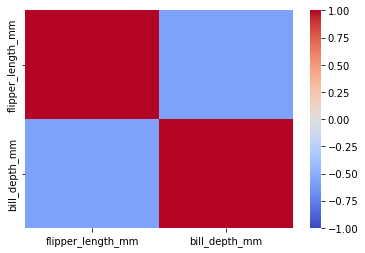

```python
fig, ax = plt.subplots()

sns.heatmap(data = penguins.loc[:, ['flipper_length_mm', 'bill_depth_mm']].corr(),
            vmin=-1, vmax=1, center = 0,
            cmap='coolwarm',
            ax=ax)

plt.show()
```

Lastly I like to annot if we don't have dozens and dozens of variables.

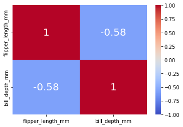

```python
fig, ax = plt.subplots()

sns.heatmap(data = penguins.loc[:, ['flipper_length_mm', 'bill_depth_mm']].corr(),
            vmin=-1, vmax=1, center = 0,
            cmap='coolwarm',
            annot=True, annot_kws={'size': 20},
            ax=ax)

plt.show()
```

### Grouped correlation plots

```python
penguins.loc[:, ['flipper_length_mm', 'bill_depth_mm', 'species']].\
groupby(['species']).\
corr()
```

| species |  | flipper_length_mm | bill_depth_mm |
| --- | --- | --- | --- |
| Adelie | flipper_length_mm | 1.000000 | 0.307620 |
|  | bill_depth_mm | 0.307620 | 1.000000 |
| Chinstrap | flipper_length_mm | 1.000000 | 0.580143 |
|  | bill_depth_mm | 0.580143 | 1.000000 |
| Gentoo | flipper_length_mm | 1.000000 | 0.706563 |
|  | bill_depth_mm | 0.706563 | 1.000000 |

```python
the_species = penguins.species.unique().tolist()

print( the_species )
```

```
['Adelie', 'Chinstrap', 'Gentoo']
```

```python
corr_per_species = penguins.loc[:, ['flipper_length_mm', 'bill_depth_mm', 'species']].groupby(['species']).corr()
```

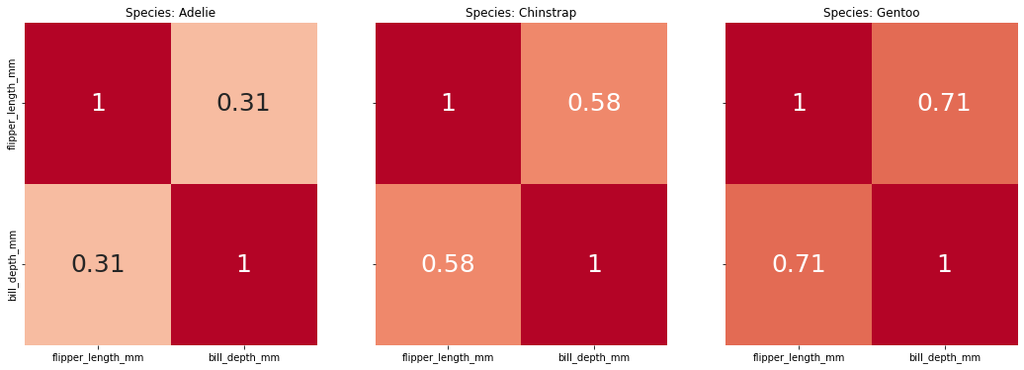

```python
fig, axs = plt.subplots(1, len(the_species), figsize=(18,6), sharex=True, sharey=True)

for ix, x in enumerate(the_species):
    sns.heatmap(data = corr_per_species.loc[x],
                vmin=-1, vmax=1, center=0,
                cmap='coolwarm', cbar=False,
                annot=True, annot_kws={'size': 25},
                ax=axs[ix])

    axs[ix].set_title('Species: '+x)

plt.show()
```

## 2D Histograms

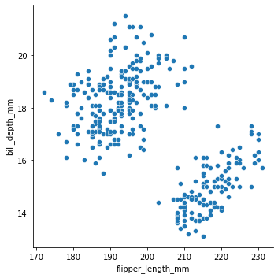

```python
sns.relplot(data = penguins, x='flipper_length_mm', y='bill_depth_mm')

plt.show()
```

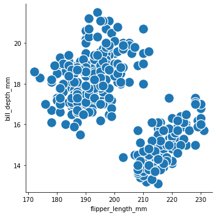

```python
sns.relplot(data = penguins, x='flipper_length_mm', y='bill_depth_mm', s=250)

plt.show()
```

Change the transparency of the markers to help display **density** or **concentration** of the observations.

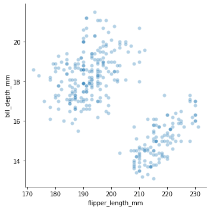

```python
sns.relplot(data = penguins, x='flipper_length_mm', y='bill_depth_mm', alpha=0.33)

plt.show()
```

The 2D histogram is intended to show the **density** via counts. Discretizes the space and counts the number of observations per bin.

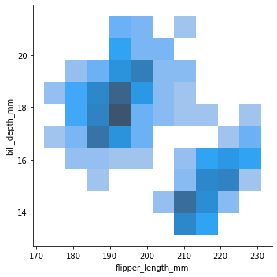

```python
sns.displot(data = penguins, x='flipper_length_mm', y='bill_depth_mm', kind='hist')

plt.show()
```

Turn on the color bar legend to show the counts.

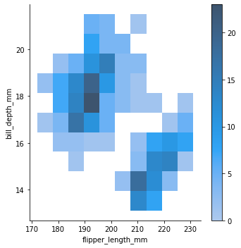

```python
sns.displot(data = penguins, x='flipper_length_mm', y='bill_depth_mm', kind='hist', cbar=True)

plt.show()
```

We can easily facet by grouping variables with the figure level function.

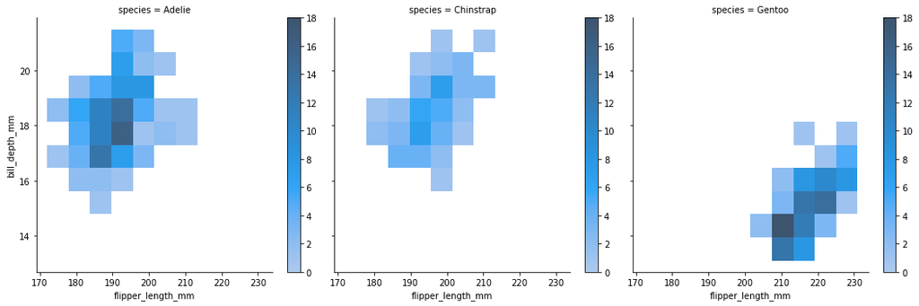

```python
sns.displot(data = penguins, x='flipper_length_mm', y='bill_depth_mm', col='species',
            kind='hist', cbar=True)

plt.show()
```

2D density plot smoothes out the histogram.

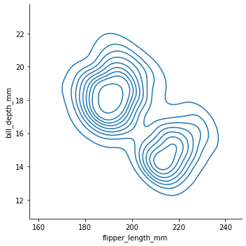

```python
sns.displot(data = penguins, x='flipper_length_mm', y='bill_depth_mm', kind='kde')

plt.show()
```

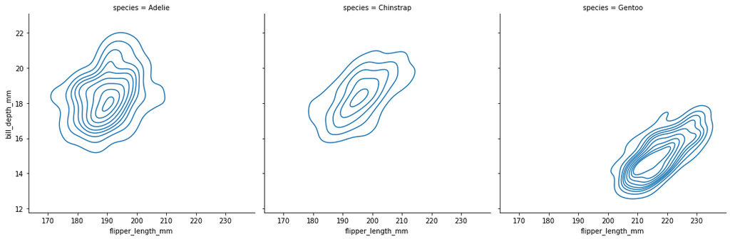

```python
sns.displot(data = penguins, x='flipper_length_mm', y='bill_depth_mm', kind='kde', col='species')

plt.show()
```

Color by a grouping variable to show everything on 1 plot.

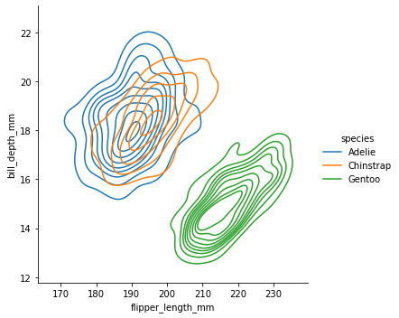

```python
sns.displot(data = penguins, x='flipper_length_mm', y='bill_depth_mm', kind='kde', hue='species')

plt.show()
```

Seaborn can combine relationships with **marginal** behavior with the **joint plot**.

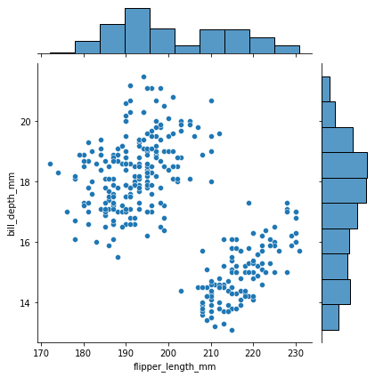

```python
sns.jointplot(data = penguins, x='flipper_length_mm', y='bill_depth_mm')

plt.show()
```

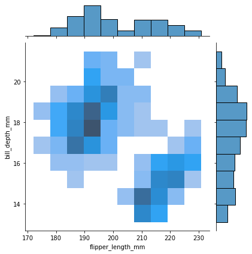

```python
sns.jointplot(data = penguins, x='flipper_length_mm', y='bill_depth_mm', kind='hist')

plt.show()
```

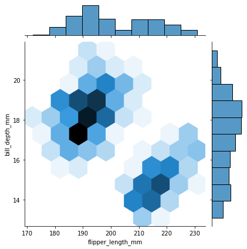

```python
sns.jointplot(data = penguins, x='flipper_length_mm', y='bill_depth_mm', kind='hex')

plt.show()
```

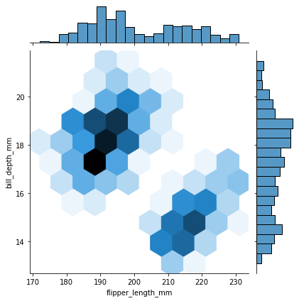

```python
sns.jointplot(data = penguins, x='flipper_length_mm', y='bill_depth_mm', kind='hex',
              marginal_kws={'bins': 21})

plt.show()
```

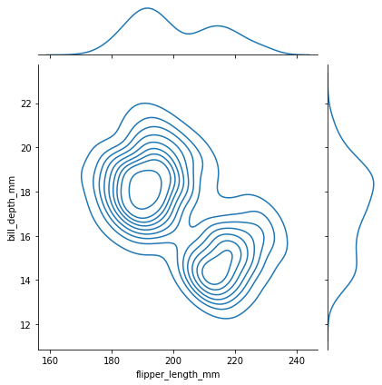

```python
sns.jointplot(data = penguins, x='flipper_length_mm', y='bill_depth_mm', kind='kde')

plt.show()
```

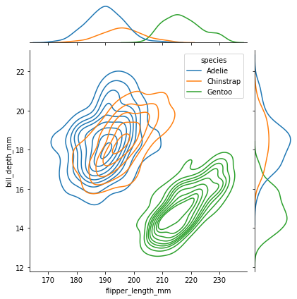

```python
sns.jointplot(data = penguins, x='flipper_length_mm', y='bill_depth_mm', hue='species',
              kind='kde')

plt.show()
```

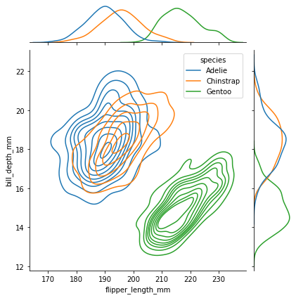

```python
sns.jointplot(data = penguins, x='flipper_length_mm', y='bill_depth_mm', hue='species',
              marginal_kws={'common_norm': False},
              kind='kde')

plt.show()
```